# project SML

Octa Syahira

2026-06-04

# 1. DESKRIPSI DATASET

Dataset yang digunakan dalam penelitian ini adalah Glass Identification Dataset yang diperoleh dari UCI Machine Learning Repository. Dataset tersebut berisi informasi mengenai karakteristik fisik dan komposisi kimia berbagai jenis kaca yang digunakan untuk mengidentifikasi kategori kaca berdasarkan unsur-unsur penyusunnya.

Dataset terdiri atas 214 observasi dan 10 variabel, yaitu sembilan variabel numerik dan satu variabel kategorik. Variabel numerik yang digunakan meliputi RI (Refractive Index), Na (Sodium), Mg (Magnesium), Al (Aluminium), Si (Silicon), K (Potassium), Ca (Calcium), Ba (Barium), dan Fe (Iron). Sementara itu, variabel Type menunjukkan jenis kaca dan digunakan sebagai informasi tambahan.

Tujuan analisis ini adalah mengelompokkan sampel kaca berdasarkan kemiripan karakteristik fisik dan kandungan unsur kimianya menggunakan metode Hierarchical Clustering.

# 2. PERSIAPAN DATA

## 2.1 Instalasi Package

Tahap awal analisis dilakukan dengan memastikan package yang diperlukan telah terinstal, yaitu tidyverse, cluster, dan factoextra. Package tersebut digunakan untuk pengolahan data, pembentukan cluster, serta visualisasi hasil analisis. Setelah terinstal, package dipanggil menggunakan fungsi library() sebelum proses analisis dilakukan.

## 2.2 Pemanggilan Package

Setelah package terinstal, package dipanggil ke dalam lingkungan kerja R.

```r
library(tidyverse)
library(cluster)
library(factoextra)
```

Pemanggilan package dilakukan agar seluruh fungsi yang diperlukan selama analisis dapat digunakan.

## 2.3 Import Data

Dataset diimpor ke dalam R menggunakan fungsi read.csv().

```r
glass <- read.csv(
  "C:/Users/LENOVO/OneDrive/Documents/glass (1).csv"
)
```

Data yang telah berhasil diimpor disimpan ke dalam objek bernama glass.

## 2.4 Eksplorasi Data

Eksplorasi data dilakukan untuk mengetahui struktur dan karakteristik awal dataset.

```r
head(glass)
```

```
##        RI    Na   Mg   Al    Si    K   Ca Ba   Fe Type
## 1 1.52101 13.64 4.49 1.10 71.78 0.06 8.75  0 0.00    1
## 2 1.51761 13.89 3.60 1.36 72.73 0.48 7.83  0 0.00    1
## 3 1.51618 13.53 3.55 1.54 72.99 0.39 7.78  0 0.00    1
## 4 1.51766 13.21 3.69 1.29 72.61 0.57 8.22  0 0.00    1
## 5 1.51742 13.27 3.62 1.24 73.08 0.55 8.07  0 0.00    1
## 6 1.51596 12.79 3.61 1.62 72.97 0.64 8.07  0 0.26    1
```

```r
str(glass)
```

```
## 'data.frame':    214 obs. of  10 variables:
##  $ RI  : num  1.52 1.52 1.52 1.52 1.52 ...
##  $ Na  : num  13.6 13.9 13.5 13.2 13.3 ...
##  $ Mg  : num  4.49 3.6 3.55 3.69 3.62 3.61 3.6 3.61 3.58 3.6 ...
##  $ Al  : num  1.1 1.36 1.54 1.29 1.24 1.62 1.14 1.05 1.37 1.36 ...
##  $ Si  : num  71.8 72.7 73 72.6 73.1 ...
##  $ K   : num  0.06 0.48 0.39 0.57 0.55 0.64 0.58 0.57 0.56 0.57 ...
##  $ Ca  : num  8.75 7.83 7.78 8.22 8.07 8.07 8.17 8.24 8.3 8.4 ...
##  $ Ba  : num  0 0 0 0 0 0 0 0 0 0 ...
##  $ Fe  : num  0 0 0 0 0 0.26 0 0 0 0.11 ...
##  $ Type: int  1 1 1 1 1 1 1 1 1 1 ...
```

```r
summary(glass)
```

```
##        RI              Na              Mg              Al
##  Min.   :1.511   Min.   :10.73   Min.   :0.000   Min.   :0.290
##  1st Qu.:1.517   1st Qu.:12.91   1st Qu.:2.115   1st Qu.:1.190
##  Median :1.518   Median :13.30   Median :3.480   Median :1.360
##  Mean   :1.518   Mean   :13.41   Mean   :2.685   Mean   :1.445
##  3rd Qu.:1.519   3rd Qu.:13.82   3rd Qu.:3.600   3rd Qu.:1.630
##  Max.   :1.534   Max.   :17.38   Max.   :4.490   Max.   :3.500
##        Si              K                Ca               Ba
##  Min.   :69.81   Min.   :0.0000   Min.   : 5.430   Min.   :0.000
##  1st Qu.:72.28   1st Qu.:0.1225   1st Qu.: 8.240   1st Qu.:0.000
##  Median :72.79   Median :0.5550   Median : 8.600   Median :0.000
##  Mean   :72.65   Mean   :0.4971   Mean   : 8.957   Mean   :0.175
##  3rd Qu.:73.09   3rd Qu.:0.6100   3rd Qu.: 9.172   3rd Qu.:0.000
##  Max.   :75.41   Max.   :6.2100   Max.   :16.190   Max.   :3.150
##        Fe               Type
##  Min.   :0.00000   Min.   :1.00
##  1st Qu.:0.00000   1st Qu.:1.00
##  Median :0.00000   Median :2.00
##  Mean   :0.05701   Mean   :2.78
##  3rd Qu.:0.10000   3rd Qu.:3.00
##  Max.   :0.51000   Max.   :7.00
```

```r
dim(glass)
```

```
## [1] 214  10
```

```r
names(glass)
```

```
##  [1] "RI"   "Na"   "Mg"   "Al"   "Si"   "K"    "Ca"   "Ba"   "Fe"   "Type"
```

Berdasarkan hasil eksplorasi, dataset terdiri atas 214 observasi dan 10 variabel. Seluruh variabel prediktor bertipe numerik, sedangkan variabel Type menunjukkan kategori jenis kaca.

Variabel RI memiliki nilai minimum sebesar 1,511, nilai maksimum sebesar 1,534, dan rata-rata sebesar 1,518. Variabel Na memiliki rata-rata sebesar 13,41, sedangkan Mg memiliki rata-rata sebesar 2,69.

Variabel Si memiliki rata-rata sebesar 72,65 dengan rentang nilai antara 69,81 hingga 75,41. Selain itu, variabel K memiliki nilai maksimum sebesar 6,21, jauh lebih besar dibandingkan nilai rata-ratanya yaitu 0,497, yang menunjukkan adanya beberapa sampel dengan kandungan kalium yang sangat tinggi.

Dataset memiliki nama variabel sebagai berikut:

```r
names(glass)
```

```
##  [1] "RI"   "Na"   "Mg"   "Al"   "Si"   "K"    "Ca"   "Ba"   "Fe"   "Type"
```

Jumlah observasi dan variabel ditunjukkan oleh:

```r
dim(glass)
```

```
## [1] 214  10
```

yang menghasilkan:

214 observasi 10 variabel

## 2.5 Transformasi Variabel Kategorik

Variabel Type diubah menjadi factor agar dikenali sebagai variabel kategorik.

```r
glass$Type <- as.factor(glass$Type)
```

Transformasi ini dilakukan karena variabel Type merupakan label kategori dan tidak digunakan dalam proses pembentukan cluster.

## 2.6 Pemeriksaan Missing Value

Pemeriksaan missing value dilakukan untuk memastikan tidak terdapat data yang hilang.

```r
sum(is.na(glass))
```

```
## [1] 0
```

Hasil pemeriksaan menunjukkan nilai 0, sehingga dapat disimpulkan bahwa seluruh data tersedia secara lengkap dan tidak memerlukan proses penanganan missing value.

## 2.7 Pemilihan Variabel Clustering

Variabel Type tidak digunakan dalam proses clustering karena merupakan label kategori.

```r
glass_clust <- glass %>%
  select(
    RI, Na, Mg, Al,
    Si, K, Ca, Ba, Fe
  )
```

Dengan demikian, analisis clustering hanya menggunakan sembilan variabel numerik.

## 2.8 Standardisasi Data

Karena setiap variabel memiliki satuan dan rentang nilai yang berbeda, maka dilakukan standardisasi data menggunakan metode z-score.

```r
glass_scale <- scale(glass_clust)
summary(glass_scale)
```

```
##        RI                Na                Mg                Al
##  Min.   :-2.3759   Min.   :-3.2793   Min.   :-1.8611   Min.   :-2.3132
##  1st Qu.:-0.6068   1st Qu.:-0.6127   1st Qu.:-0.3948   1st Qu.:-0.5106
##  Median :-0.2257   Median :-0.1321   Median : 0.5515   Median :-0.1701
##  Mean   : 0.0000   Mean   : 0.0000   Mean   : 0.0000   Mean   : 0.0000
##  3rd Qu.: 0.2608   3rd Qu.: 0.5108   3rd Qu.: 0.6347   3rd Qu.: 0.3707
##  Max.   : 5.1252   Max.   : 4.8642   Max.   : 1.2517   Max.   : 4.1162
##        Si                K                  Ca                Ba
##  Min.   :-3.6679   Min.   :-0.76213   Min.   :-2.4783   Min.   :-0.3521
##  1st Qu.:-0.4789   1st Qu.:-0.57430   1st Qu.:-0.5038   1st Qu.:-0.3521
##  Median : 0.1795   Median : 0.08884   Median :-0.2508   Median :-0.3521
##  Mean   : 0.0000   Mean   : 0.00000   Mean   : 0.0000   Mean   : 0.0000
##  3rd Qu.: 0.5636   3rd Qu.: 0.17318   3rd Qu.: 0.1515   3rd Qu.:-0.3521
##  Max.   : 3.5622   Max.   : 8.75961   Max.   : 5.0824   Max.   : 5.9832
##        Fe
##  Min.   :-0.5851
##  1st Qu.:-0.5851
##  Median :-0.5851
##  Mean   : 0.0000
##  3rd Qu.: 0.4412
##  Max.   : 4.6490
```

Hasil standardisasi menunjukkan bahwa seluruh variabel memiliki rata-rata mendekati nol dan simpangan baku mendekati satu. Standardisasi diperlukan agar seluruh variabel memiliki kontribusi yang seimbang dalam perhitungan jarak.

# 3. ANALISIS HIERARCHICAL CLUSTERING

## 3.1 Perhitungan Jarak Euclidean

Jarak antar objek dihitung menggunakan metode Euclidean Distance.

```r
d <- dist(
  glass_scale,
  method = "euclidean"
)
```

Jarak Euclidean digunakan untuk mengukur tingkat kemiripan antar sampel berdasarkan seluruh variabel numerik yang digunakan.

## 3.2 Pembentukan Hierarchical Clustering

Proses clustering dilakukan menggunakan metode Ward.D2.

```r
hc <- hclust(
  d,
  method = "ward.D2"
)
```

Metode Ward dipilih karena mampu menghasilkan kelompok yang relatif homogen dengan meminimalkan variasi di dalam cluster.

## 3.3 Dendrogram Hierarchical Clustering

Hasil hierarchical clustering divisualisasikan menggunakan dendrogram.

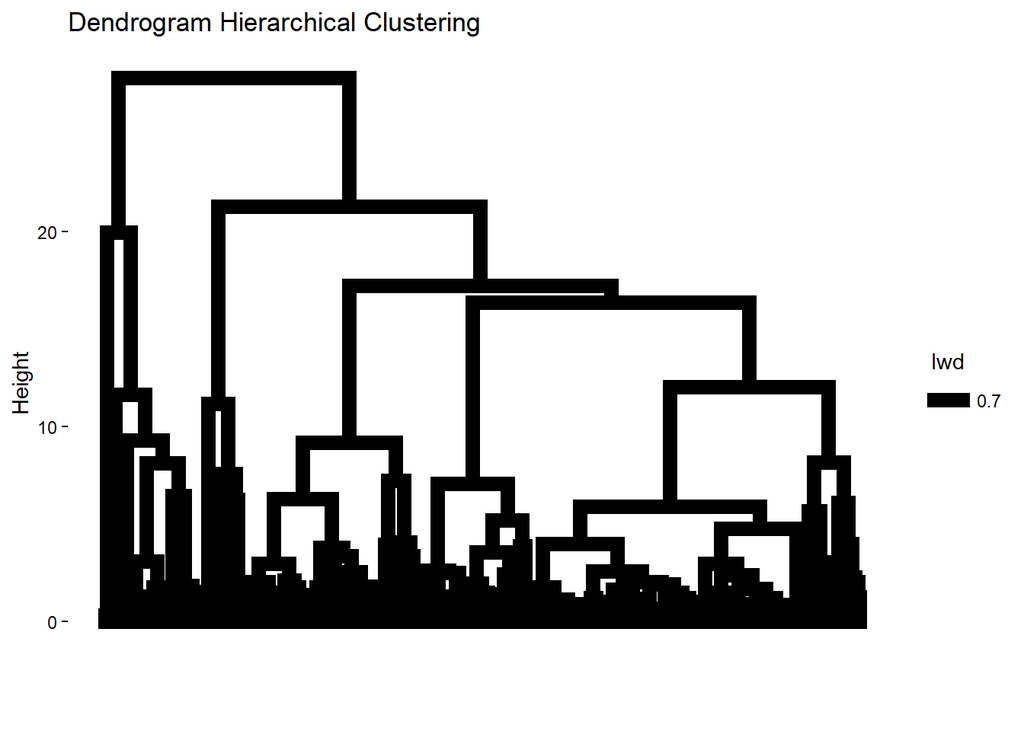

```r
fviz_dend(
  hc,
  show_labels = FALSE,
  main = "Dendrogram Hierarchical Clustering"
)
```

## 3.4 Penentuan Jumlah Cluster Optimal

Jumlah cluster optimal ditentukan menggunakan metode Average Silhouette Width.

```r
sil_width <- c()

for(k in 2:10){

  cluster_k <- cutree(
    hc,
    k = k
  )

  sil <- silhouette(
    cluster_k,
    d
  )

  sil_width[k] <- mean(
    sil[,3]
  )
}
```

```r
hasil_silhouette <- data.frame(
  Cluster = 2:10,
  Silhouette = sil_width[2:10]
)
```

## 3.5 Grafik Average Silhouette Width

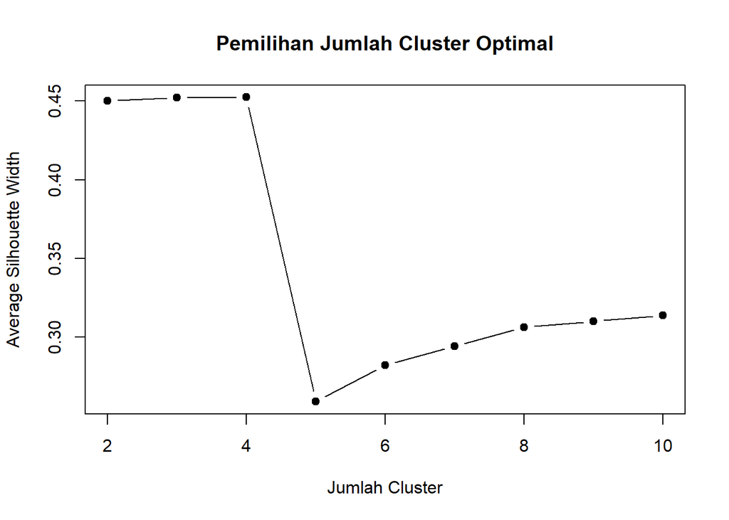

```r
plot(
  2:10,
  sil_width[2:10],
  type = "b",
  pch = 19,
  xlab = "Jumlah Cluster",
  ylab = "Average Silhouette Width",
  main = "Pemilihan Jumlah Cluster Optimal"
)
```

Berdasarkan metode Silhouette, jumlah cluster optimal pada dataset Glass adalah 4 cluster dengan nilai Average Silhouette Width sekitar 0,45.

## 3.6 Pembentukan Cluster Akhir

Jumlah cluster optimal yang diperoleh kemudian digunakan untuk membentuk cluster akhir.

```r
best_k <- hasil_silhouette$Cluster[
  which.max(
    hasil_silhouette$Silhouette
  )
]

best_k
```

```
## [1] 4
```

```r
cluster_final <- cutree(
  hc,
  k = best_k
)
```

Distribusi anggota cluster adalah sebagai berikut.

```r
table(cluster_final)
```

```
## cluster_final
##   1   2   3   4
## 175  10  27   2
```

Cluster 1 merupakan cluster terbesar dengan proporsi sekitar 81,8% dari seluruh data.

## 3.7 Dendrogram Cluster Optimal

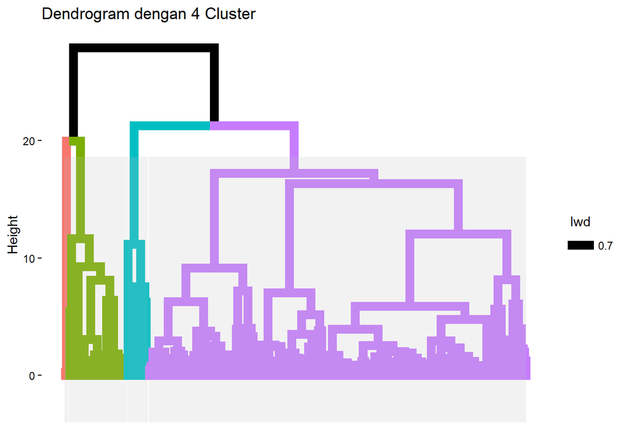

```r
fviz_dend(
  hc,
  k = best_k,
  rect = TRUE,
  rect_fill = TRUE,
  show_labels = FALSE,
  main = paste(
    "Dendrogram dengan",
    best_k,
    "Cluster"
  )
)
```

Berdasarkan dendrogram, data Glass dapat dikelompokkan menjadi 4 cluster yang berbeda. Penggabungan cluster terjadi pada nilai Height yang relatif tinggi, menunjukkan adanya perbedaan karakteristik yang cukup jelas antar kelompok. Sebagian besar objek berada pada satu cluster besar, sedangkan cluster lainnya memiliki anggota yang lebih sedikit. Hasil ini menunjukkan bahwa dataset Glass memiliki struktur pengelompokan yang cukup baik dan dapat dibedakan berdasarkan kemiripan karakteristiknya.

## 3.8 Visualisasi Cluster

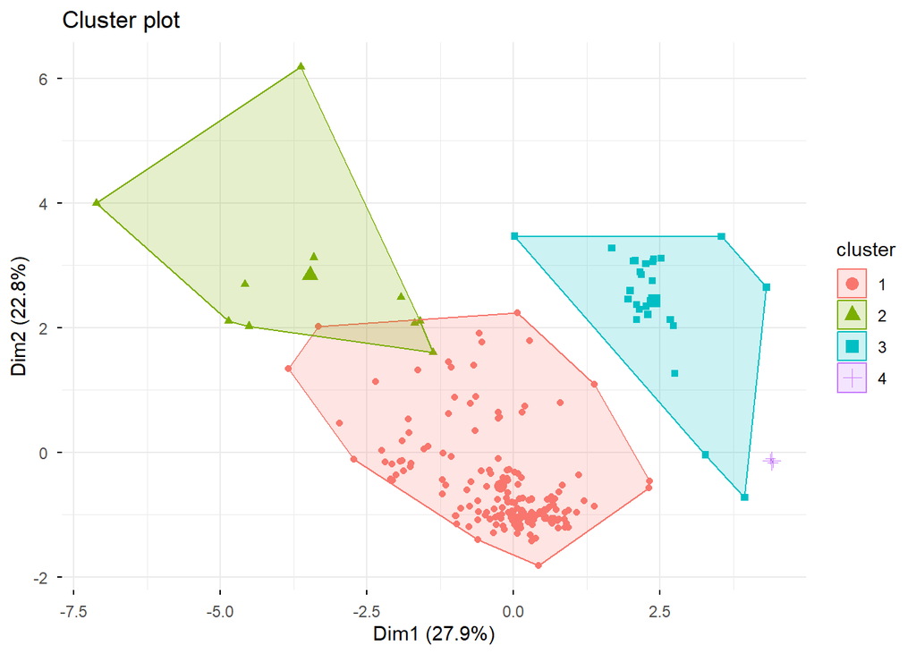

```r
fviz_cluster(
  list(
    data = glass_scale,
    cluster = cluster_final
  ),
  geom = "point",
  ellipse.type = "convex",
  ggtheme = theme_minimal()
)
```

## 3.9 Evaluasi Silhouette

```
##   cluster size ave.sil.width
## 1       1  175          0.48
## 2       2   10          0.19
## 3       3   27          0.36
## 4       4    2          0.97
```

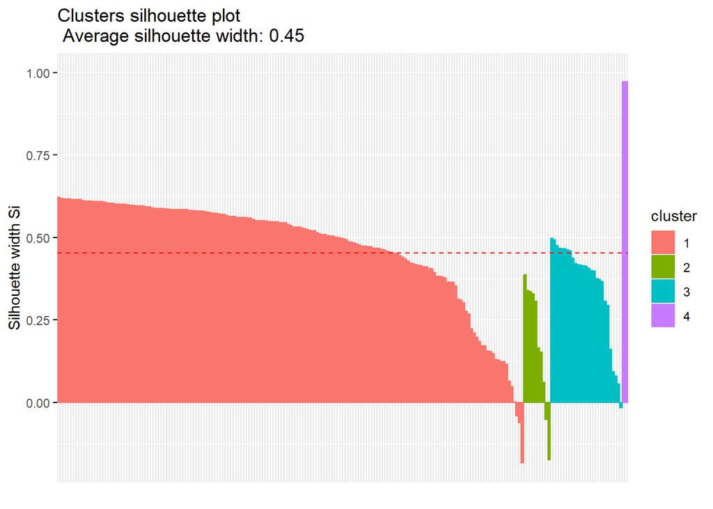

```r
sil_final <- silhouette(
  cluster_final,
  d
)

fviz_silhouette(
  sil_final
)
```

Hasil evaluasi menggunakan metode silhouette menunjukkan bahwa pembentukan 4 cluster menghasilkan nilai average silhouette width sebesar 0,45. Nilai ini mengindikasikan bahwa struktur cluster yang terbentuk sudah cukup baik karena sebagian besar observasi memiliki nilai silhouette positif. Namun, masih terdapat beberapa observasi dengan nilai silhouette rendah atau negatif yang menunjukkan adanya tumpang tindih antar cluster. Secara umum, pengelompokan data Glass mampu membedakan karakteristik objek dengan cukup baik, meskipun pemisahan antar beberapa cluster belum sepenuhnya optimal.

Nilai silhouette rata-rata keseluruhan diperoleh sebesar:

```r
mean(
  sil_final[,3]
)
```

```
## [1] 0.4523495
```

Nilai tersebut menunjukkan bahwa hasil clustering memiliki kualitas yang cukup baik karena objek dalam setiap cluster relatif lebih mirip dengan anggota cluster yang sama dibandingkan cluster lainnya.

## 3.10 Karakteristik Cluster

Karakteristik cluster dianalisis menggunakan nilai rata-rata masing-masing variabel.

```r
glass_clustered <- cbind(
  glass_clust,
  Cluster = factor(cluster_final)
)

karakteristik_cluster <- aggregate(
  . ~ Cluster,
  data = glass_clustered,
  mean
)

karakteristik_cluster
```

```
##   Cluster       RI       Na        Mg       Al       Si         K        Ca
## 1       1 1.518276 13.26034 3.2143429 1.325886 72.66789 0.4849714  8.834000
## 2       2 1.526123 12.66200 0.1010000 1.199000 71.88500 0.2030000 13.437000
## 3       3 1.516459 14.66963 0.4062963 2.190000 72.97741 0.2611111  8.243704
## 4       4 1.513185 13.01000 0.0000000 3.030000 70.59000 6.2100000  6.945000
##           Ba         Fe
## 1 0.01548571 0.06348571
## 2 0.31500000 0.07000000
## 3 1.17037037 0.01444444
## 4 0.00000000 0.00000000
```

## 3.11 Boxplot Karakteristik Cluster

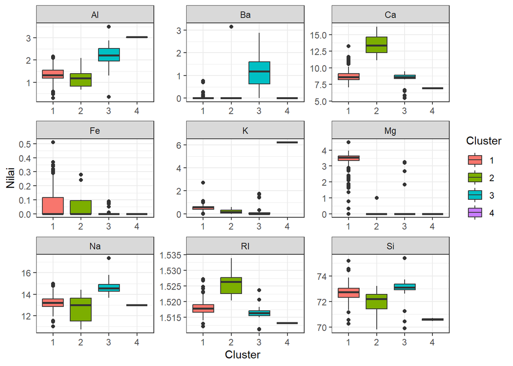

```r
glass_long <- glass_clustered %>%
  pivot_longer(
    cols = -Cluster,
    names_to = "Variabel",
    values_to = "Nilai"
  )

ggplot(
  glass_long,
  aes(
    x = Cluster,
    y = Nilai,
    fill = Cluster
  )
) +
  geom_boxplot() +
  facet_wrap(
    ~Variabel,
    scales = "free"
  ) +
  theme_bw()
```

## 3.12 Penyimpanan Hasil

```r
write.csv(
  glass,
  "hasil_clustering_glass.csv",
  row.names = FALSE
)
```